# A Replication of Griskevicius et al’s (2010) study: Being Green to be Seen

*N* removed NAs: 5

*N* removed <18: 32

**Correct typo age:** 22

*N* total clean: 131

| Group | *N* | *M*<sub>age</sub> | % green |
| --- | --- | --- | --- |
| Control | 64 | 21.05 | 36.46 |
| Experim | 67 | 20.90 | 48.26 |

| Gender | *N* | *M*<sub>age</sub> | % green |
| --- | --- | --- | --- |
| Male | 70 | 20.60 | 42.86 |
| Female | 37 | 21.70 | 46.85 |
| Other | 24 | 20.92 | 34.72 |

**Main analysis results**

**car:**  
χ<sup>2</sup>(1) = 1.82, *p* = .177

**cleaner:**  
χ<sup>2</sup>(1) = 2.45, *p* = .118

**dishwasher:**  
χ<sup>2</sup>(1) = 0.43, *p* = .511

[interactive chart not shown]

[figure not shown]

[interactive chart not shown]

# A Replication of Griskevicius et al’s (2010) study: Being Green to be Seen

Analysing Data, Spring 2020

# Methods

## Participants

Table 1 *Descriptive statistics by Gender*

[output not shown]

## Design

The purpose of this study is to investigate whether Griskevicius et al.’s (2010) study “Going green to be seen”, can be successfully replicated to conceive similar results. This study will specifically focus on the ‘Experiment 1’ from the aforementioned paper, which concentrated on the willingness to buy pro-environmental (or green) products and how these buying patterns are linked to a desire for high social status.

As conducted in Griskevicius et al.’s (2010) experiment, this study participants will be randomly assigned one of two conditions. The activating status condition participants will read story that “elicits desire for social status” about working their way up in a company and the control condition will read a non-stimulating neutral story about losing a concert ticket. In the original study to ensure the control story had no effect on the potential results an extra control condition was added with no story and as predicted the two control conditions did not differ from each other, making any potential dependent variables null. After priming both conditions will then be asked to choose between a green or luxury option for three types of product; car, cleaner, dishwasher. The independent variable is which story condition the participants are assigned to, regulating which story they will read before making their decision, and the dependent variable is their choice of product category; luxury vs green. Due to there being two categorical variables being investigated in this study, a chi-squared test will be utilised to analyse the collected data.

In Griskevicius et al.’s (2010) original study they predicted that the likelihood of choosing green products will increase due to activating status motives relative to the same products in the control group. Their results were significant and supported these claims as 54.5% of participants in the active status condition chose the green car, compared to only 37.2% in the control group. Similar results were found for household cleaner (41.8% active status compared to 25.7% control) and for dishwasher (49.1% for active status compared to 34.5% control).

Therefore, in this replication we expect similar results in that participants in the active status condition will be more likely to choose the green products over the luxury products, compared to the control condition.

# Results

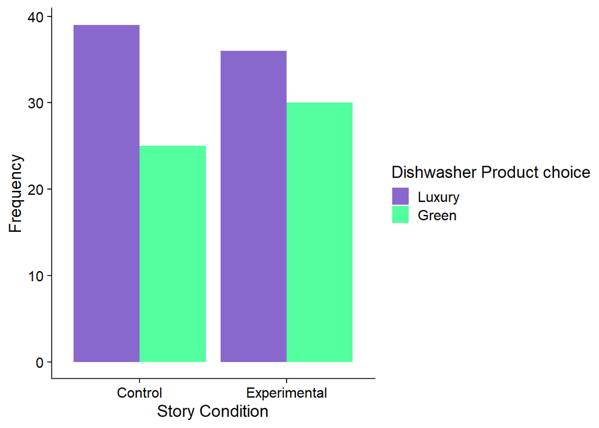

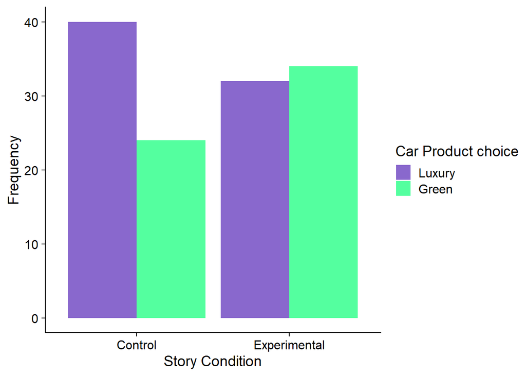

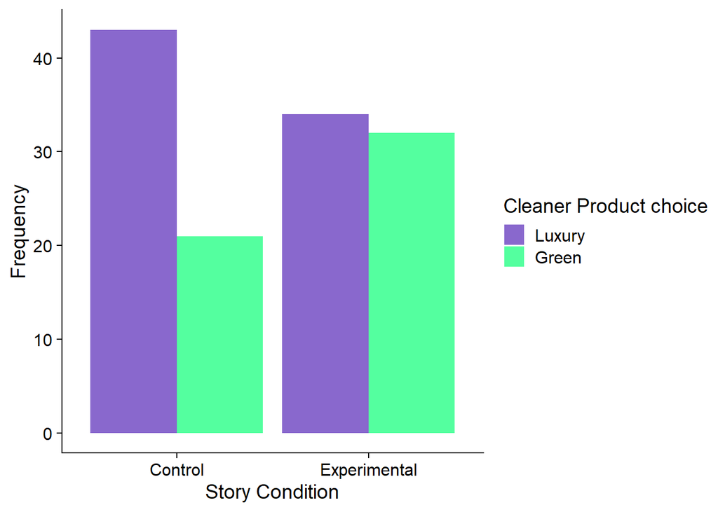

# Discussion

From the results we can see that there is no significant effect on consumer choices for green products in relation to high-status motives. As all three products produced non-significant results in this replication study. It can be determined from these non-significant results that high status motives are not a consistent striving factor in the choosing of green products. Although there was a positive difference and a similar pattern of results to the original study in the two conditions, the lack of statistic significant is prevalent.

However, this difference does not nullify the original study’s conclusions as both findings can be considered valid independent of significant results as we can infer that other external factors may have caused the difference in the results rather than experimental or theoretical errors (Griskevicius et al.’s 2010). Thus, leaving the field open to explore various external factors that could impact consumer purchases and choices of environmentally friendly products. Due to altruism and high-status striving not being as a significant motive as originally thought, future research should consider universal personality dimensions, such as the Big Five, to be a strong motivational factor (Miller, 2009 cited by Brick & Lewis, 2014). Griskevicius et al.’s (2010) also suggested this as a possible limitation and acknowledged that further research is needed.

These conclusions suggest that environmentally friendly behaviour is multidimensional and possibly too diverse to consider only one factor (Brick & Lewis, 2014; Brick, Sherman & Kim, 2017). This is a growing area of research considers personality factors such as, Openness and Conscientiousness to independently predict environmentalist behaviours, and mediate their effects by pro-environmental attitudes (Brick & Lewis, 2014). Openness reflects rich and abstract thinking with an appreciation for variety and unusual experiences, whereas Conscientiousness is indicated by high levels of self-discipline, respect for duty, and desire for achievement, all of which are relevant to self-identity and high-status motives (Brick & Lewis, 2014). Therefore, it could be inferred that participant’s personality factors could have affected whether they would normally choose green products and whether the activating story would have influenced them.

Continually another study found that the environmentalist identity was associated with more pro-environmental behaviour, therefore an individual’s ethics and beliefs about the environment should be considered for the reasoning for choosing green products as well as high status motives (Brick, Sherman & Kim, 2017). Also, this paper found that supporting the idea of protecting the environment, having a sense of responsibility towards the environment, taking an interest to experience green products and social request are among the most important factors in decisions to buy green products (Shahbazi & Eidi, 2017). Further research into consumer ethics found the difference between those who picked green products over luxury products had a significant difference in their ethical perceptions, also they compared their attitudes towards businesses therefore providing possible reasoning as to why the high status motive story about working your way up in a business had little effect on consumer choices in our replica study (Vitell & Muncy, 2005). Therefore, supporting the reasoning to further consider personal environmental ethics as a distinguishable factor in buying green products, due to previous ethics beliefs being a possible explanation to why our result was non-significant.

One limitation of our research is that our experiments did not involve the actual purchasing of the products. Therefore, this study lacks ecological validity due to the laboratory environment and the hypothetical scenarios, further research is welcomed to explore this. A study by van der Wal, van Horena & Grinstein (2016) also replicated the findings of Griskevicius et al. (2010) but in a real-world shopping context. They found that shoppers at a high-status sustainable grocery chain used more branded shopping bags than shoppers of a lower-status sustainable store. This demonstrates that the behaviour results from the hypothetical lab situation in the original paper does infact represent a behaviour that exists in real world environments and therefore provides generalisability and external validity to previous findings (VanderWal, VanHorena & Grinstein, 2016). However, both these papers fail to look at the individual motivations and characteristics in why they choose sustainable brands.

Therefore, leading into another limitation, which is the lack of pre-screening for the participant sample as a person’s income may also be a factor in choosing more expensive environmentally friendly products, as those with limited income tend to purchase the generic or store brand because the cost is cheaper (Conway-Branch, 2018). Also, as previously mentioned, a person’s environmental ethics and personality may also be a factor in their choosing of green products over luxury (Brick, Sherman & Kim, 2017; Brick & Lewis, 2014). Therefore, possible areas for future research should consider the possibility that each of these influences could be a deciding factor in the reason for choosing green products alongside high-status motives.

Based on previous research high status motives have the ability to motivate some people to buy green products. However, without further research that considers the possible role of personality factors (high openness & high conscientiousness) and the effect of personal environmental ethics, it is difficult to understand their direct effect due to this multicausal individual interest.

# References

Brick, C., & Lewis, G. (2016). Unearthing the “Green” Personality: Core Traits Predict Environmentally Friendly Behavior. *Environment and Behavior, 48*(5), 635-658.

Brick, C., Sherman, D., & Kim, H. (2017). “Green to be seen” and “brown to keep down”: Visibility moderates the effect of identity on pro-environmental behavior. *Journal of Environmental Psychology, 51*(C), 226-238.

Conway-Branch, C. 2018, *Are Green Products Affordable for Low-Income Ethnic Consumers?*, Northcentral University.

Eidi, F., & Shahbazi, A. (2017). Effective Factors on Consumers’ Decision to Buy Green Products. *International Journal of Economic Perspectives, 11*(1), 795-807.

Griskevicius, V., Tybur, J., & Van den Bergh, B. (2010). Going Green to Be Seen: Status, Reputation, and Conspicuous Conservation. *Journal of Personality and Social Psychology, 98*(3), 392-404.

VanderWal, A., VanHoren, F., & Grinstein, A. (2016). The paradox of ‘green to be seen’: Green high-status shoppers excessively use (branded) shopping bags. *International Journal of Research in Marketing, 33*(1), 216.

Vitell, S.J., Muncy, J. ‘The Muncy–Vitell Consumer Ethics Scale: A Modification and Application’. *J Bus Ethics 62, 267–275* (2005). https://doi-org.ezproxy.sussex.ac.uk/10.1007/s10551-005-7058-9